# Chapter09. 공선형 데이터의 분석

Jeong-Eun Lee

2021 7 23

### 9.1 소개

- 직교 : 예측변수들 간에 선형적인 연관관계가 전혀 없는 경우
  - 직교성의 결여는 예측변수들이 너무 강하게 연관되어 있으면 회귀분석의 결과가 애매모호해질 우려가 있음
- 공선성(or 다중공선성) : 예측변수들 간의 강한 비직교적 상태, 데이터의 결함에 의해 나타나는 결과

### 9.2 통계적 추론에 미치는 효과

- 교육기회균등 데이터(EEO 데이터)
- 목적 : 학교의 시설 환경에 관련된 요인이 학생의 학업성취도(ACHV)에 미치는 영향을 평가하는 것
- 모형 : $ACHV = \beta_0 + \beta_1 * FAM + \beta_2 * PEER + \beta_3 * SCHOOL + \epsilon$
  - 예측변수 SCHOOL에 관해 ’조정’된 학업성취도의 회귀관계로 나타내면 $ACHV - \beta_1 * FAM - \beta_2 * PEER = \beta_0 + \beta_3 * SCHOOL + \epsilon$

```r
setwd("C:/Users/X-Note/Desktop")
achv = read.table("achv.txt", header = T)
head(achv)
```

```
##       ACHV      FAM     PEER   SCHOOL
## 1 -0.43148  0.60814  0.03509  0.16607
## 2  0.79969  0.79369  0.47924  0.53356
## 3 -0.92467 -0.82630 -0.61951 -0.78635
## 4 -2.19081 -1.25310 -1.21675 -1.04076
## 5 -2.84818  0.17399 -0.18517  0.14229
## 6 -0.66233  0.20246  0.12764  0.27311
```

```r
lm_achv = lm(ACHV ~ FAM + PEER + SCHOOL, data = achv)
summary(lm_achv)
```

```
##
## Call:
## lm(formula = ACHV ~ FAM + PEER + SCHOOL, data = achv)
##
## Residuals:
##     Min      1Q  Median      3Q     Max
## -5.2096 -1.3934 -0.2947  1.1415  4.5881
##
## Coefficients:
##             Estimate Std. Error t value Pr(>|t|)
## (Intercept) -0.06996    0.25064  -0.279    0.781
## FAM          1.10126    1.41056   0.781    0.438
## PEER         2.32206    1.48129   1.568    0.122
## SCHOOL      -2.28100    2.22045  -1.027    0.308
##
## Residual standard error: 2.07 on 66 degrees of freedom
## Multiple R-squared:  0.2063, Adjusted R-squared:  0.1702
## F-statistic: 5.717 on 3 and 66 DF,  p-value: 0.001535
```

```r
anova(lm_achv)
```

```
## Analysis of Variance Table
##
## Response: ACHV
##           Df  Sum Sq Mean Sq F value    Pr(>F)
## FAM        1  62.703  62.703 14.6300 0.0002928 ***
## PEER       1   6.280   6.280  1.4652 0.2304169
## SCHOOL     1   4.523   4.523  1.0553 0.3080446
## Residuals 66 282.873   4.286
## ---
## Signif. codes:  0 '***' 0.001 '**' 0.01 '*' 0.05 '.' 0.1 ' ' 1
```

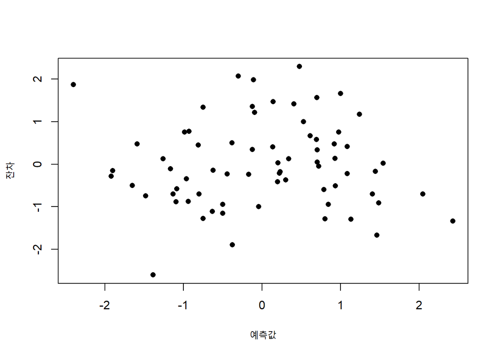

```r
plot(lm_achv$fitted.values, rstandard(lm_achv), xlab = "예측값", ylab = "잔차", pch = 16)
```

```r
cor(achv[-1])
```

```
##              FAM      PEER    SCHOOL
## FAM    1.0000000 0.9600806 0.9856837
## PEER   0.9600806 1.0000000 0.9821601
## SCHOOL 0.9856837 0.9821601 1.0000000
```

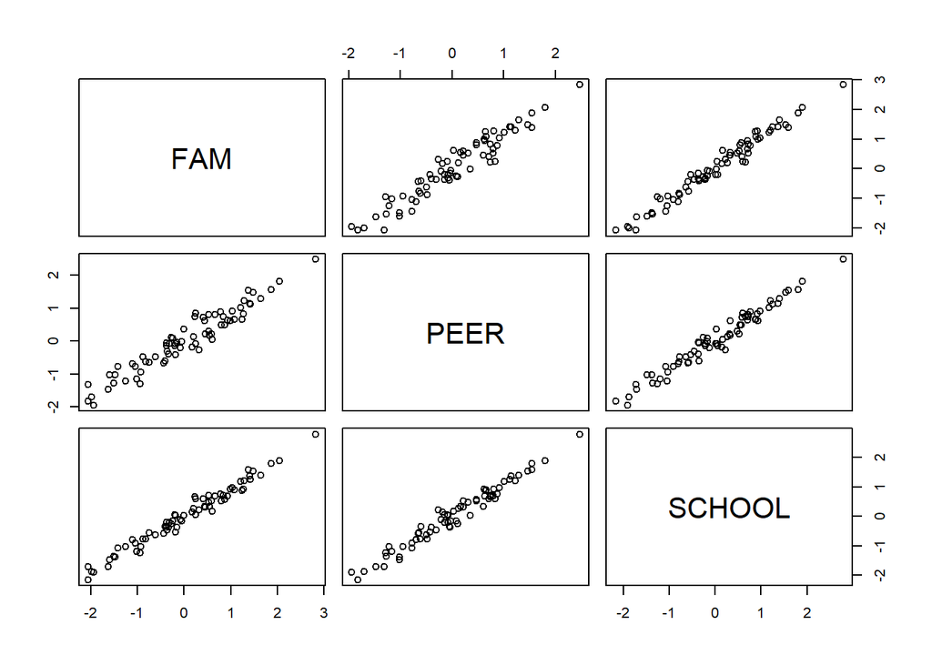

```r
pairs(achv[-1])
```

- 총 변이에 대한 예측변수의 설명비율이 약 20%($R^2 = 0.206$) 인데도 불구하고 이 결과는 예측변수 FAM, PEER, SCHOOL이 반응변수의 변이를 설명함에 유용한 역할을 하고 있음 + 각 예측변수에 대한 개별적 t-값은 모두 작음 -> 3개의 예측변수가 모두 함께 사용되었을 때 전체적으로는 유의하나 개별적으로 보았을 때는 모든 t-값은 유의하지 않음 -> 심각한 다중공선성의 상황
- 다중공선성의 발생 원인
  1. 표본 데이터의 결함 -> 관측값을 표본에 추가함으로써 해결(단, 표본은 예측변수들 간의 상관관계가 너무 크지 않도록 선정해야함)
  2. 모집단 고유의 특성으로 인하여 예측변수들 간에 원천적으로 큰 상관관계가 있는 경우

### 9.3 예측에 미치는 효과

- 프랑스 경제 데이터(IMPORT 데이터)
- 모형 : $IMPORT = \beta_0 + \beta_1 * DOPROD + \beta_2 * STOCK + \beta_3 * CONSUM + \epsilon$

```r
setwd("C:/Users/X-Note/Desktop")
france = read.table("france.txt", header = T)
head(france)
```

```
##   YEAR IMPORT DOPROD STOCK CONSUM
## 1   49   15.9  149.3   4.2  108.1
## 2   50   16.4  161.2   4.1  114.8
## 3   51   19.0  171.5   3.1  123.2
## 4   52   19.1  175.5   3.1  126.9
## 5   53   18.8  180.8   1.1  132.1
## 6   54   20.4  190.7   2.2  137.7
```

```r
lm_france = lm(IMPORT ~ DOPROD + STOCK + CONSUM, data = france)
summary(lm_france)
```

```
##
## Call:
## lm(formula = IMPORT ~ DOPROD + STOCK + CONSUM, data = france)
##
## Residuals:
##     Min      1Q  Median      3Q     Max
## -2.7208 -1.8354 -0.3479  1.2973  4.1008
##
## Coefficients:
##             Estimate Std. Error t value Pr(>|t|)
## (Intercept) -19.7251     4.1253  -4.782 0.000293 ***
## DOPROD        0.0322     0.1869   0.172 0.865650
## STOCK         0.4142     0.3223   1.285 0.219545
## CONSUM        0.2427     0.2854   0.851 0.409268
## ---
## Signif. codes:  0 '***' 0.001 '**' 0.01 '*' 0.05 '.' 0.1 ' ' 1
##
## Residual standard error: 2.258 on 14 degrees of freedom
## Multiple R-squared:  0.973,  Adjusted R-squared:  0.9673
## F-statistic: 168.4 on 3 and 14 DF,  p-value: 3.212e-11
```

```r
anova(lm_france)
```

```
## Analysis of Variance Table
##
## Response: IMPORT
##           Df  Sum Sq Mean Sq  F value    Pr(>F)
## DOPROD     1 2565.17 2565.17 503.0425 2.262e-12 ***
## STOCK      1    8.06    8.06   1.5807    0.2292
## CONSUM     1    3.69    3.69   0.7236    0.4093
## Residuals 14   71.39    5.10
## ---
## Signif. codes:  0 '***' 0.001 '**' 0.01 '*' 0.05 '.' 0.1 ' ' 1
```

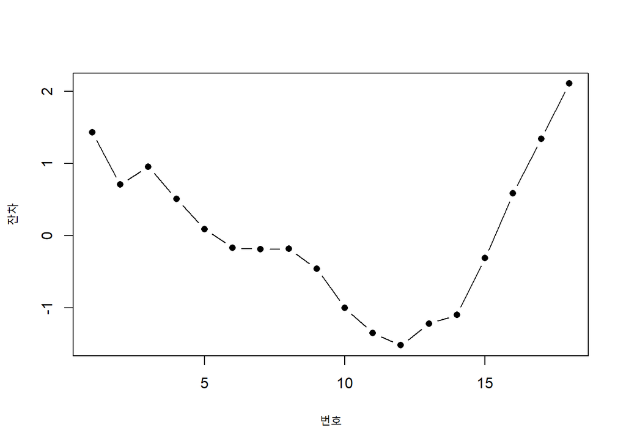

```r
plot(rstandard(lm_france), xlab = "번호", ylab = "잔차", pch = 16, type = "b")
```

- $R^2 = 0.973$은 매우 크나 이에 비해 t값이 매우 작은 결과 -> 심각한 다중공선성의 상황
- 매우 분명한 패턴(이차곡선의 패턴)의 잔차플롯 -> 1960년부터의 유럽공동시장 운영에 따른 수출입관계의 중대한 변화가 생김을 고려해야함 -> 1949년 ~ 1959년까지의 상황만을 고려하기로 함

```r
lm_france2 = lm(IMPORT[1:11] ~ DOPROD[1:11] + STOCK[1:11] + CONSUM[1:11], data = france)
summary(lm_france2)
```

```
##
## Call:
## lm(formula = IMPORT[1:11] ~ DOPROD[1:11] + STOCK[1:11] + CONSUM[1:11],
##     data = france)
##
## Residuals:
##      Min       1Q   Median       3Q      Max
## -0.52367 -0.38953  0.05424  0.22644  0.78313
##
## Coefficients:
##               Estimate Std. Error t value Pr(>|t|)
## (Intercept)  -10.12799    1.21216  -8.355  6.9e-05 ***
## DOPROD[1:11]  -0.05140    0.07028  -0.731 0.488344
## STOCK[1:11]    0.58695    0.09462   6.203 0.000444 ***
## CONSUM[1:11]   0.28685    0.10221   2.807 0.026277 *
## ---
## Signif. codes:  0 '***' 0.001 '**' 0.01 '*' 0.05 '.' 0.1 ' ' 1
##
## Residual standard error: 0.4889 on 7 degrees of freedom
## Multiple R-squared:  0.9919, Adjusted R-squared:  0.9884
## F-statistic: 285.6 on 3 and 7 DF,  p-value: 1.112e-07
```

```r
anova(lm_france2)
```

```
## Analysis of Variance Table
##
## Response: IMPORT[1:11]
##              Df  Sum Sq Mean Sq  F value    Pr(>F)
## DOPROD[1:11]  1 192.361 192.361 804.8833 1.738e-08 ***
## STOCK[1:11]   1  10.532  10.532  44.0700 0.0002936 ***
## CONSUM[1:11]  1   1.882   1.882   7.8765 0.0262771 *
## Residuals     7   1.673   0.239
## ---
## Signif. codes:  0 '***' 0.001 '**' 0.01 '*' 0.05 '.' 0.1 ' ' 1
```

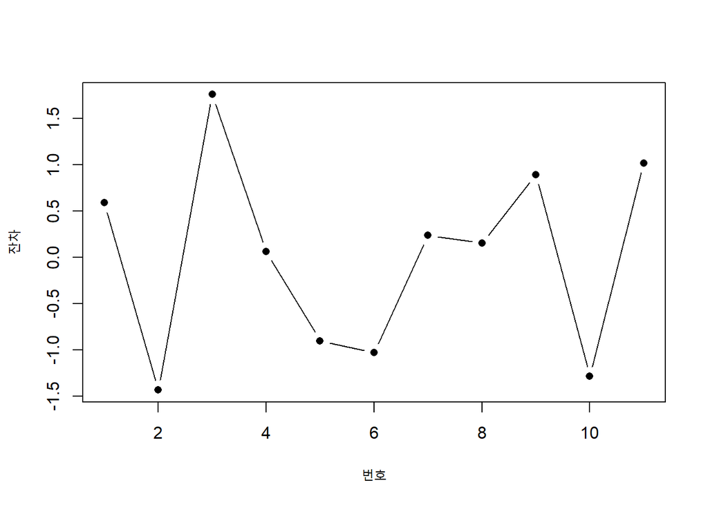

```r
plot(rstandard(lm_france2), xlab = "번호", ylab = "잔차", pch = 16, type = "b")
```

- $R^2 = 0.99$는 매우 높으나 DOPROD에 대한 회귀계수가 음수이며 통계적으로 유의하지 않은 결과 -> 경제학적으로, STOCK과 COMSUM을 고정시켰을 때 DOPROD의 증가는 IMPORT의 증가를 초래함 -> 분석 결과가 경제이론과 상호모순된 결과 -> 다중공선성의 경우

```r
cor(france$CONSUM[1:11], france$DOPROD[1:11])
```

```
## [1] 0.9972607
```

```r
lm_consum = lm(CONSUM[1:11] ~ DOPROD[1:11], data = france)
summary(lm_consum)
```

```
##
## Call:
## lm(formula = CONSUM[1:11] ~ DOPROD[1:11], data = france)
##
## Residuals:
##     Min      1Q  Median      3Q     Max
## -2.5983 -0.8628  0.2589  1.0316  2.1477
##
## Coefficients:
##              Estimate Std. Error t value Pr(>|t|)
## (Intercept)   6.25861    3.33548   1.876   0.0933 .
## DOPROD[1:11]  0.68594    0.01696  40.448 1.72e-11 ***
## ---
## Signif. codes:  0 '***' 0.001 '**' 0.01 '*' 0.05 '.' 0.1 ' ' 1
##
## Residual standard error: 1.609 on 9 degrees of freedom
## Multiple R-squared:  0.9945, Adjusted R-squared:  0.9939
## F-statistic:  1636 on 1 and 9 DF,  p-value: 1.718e-11
```

### 9.4 다중공선성의 탐색

#### 9.4.1 다중공선성의 간단한 징후 -> 다중공선성의 전체 그림을 파악하는 데는 충분하지 않음

- 경우 1) 추정된 회귀계수의 불안정성의 형태
  - 한 변수를 추가 또는 삭제할 때 추정된 회귀계수가 크게 변할 경우
  - 한 데이터 점을 변화시키거나 제거할 때 추정된 회귀계수가 크게 변화할 경우
- 경우 2) 잔차플롯을 볼 때 모형이 만족스럽게 구체화되었음이 확인
  - 추정된 회귀계수의 대수적인 부호가 사전에 기대한 (이론적인) 것과 일치하지 않을 경우
  - 이론적으로 중요한 변수에 대한 회귀계수가 큰 표준오차를 가지는 경우
- 경우 3) 예측변수들 사이의 상관계수의 크기로 통해서 검색될 수 있음
- 광고(ADVER) 데이터
  - 모형 : $S_t = \beta_0 + \beta_1A_t + \beta_2P_t + \beta_3E_t + \beta_4A_{t-1} + \beta_5P_{t-1} + \epsilon$

```r
setwd("C:/Users/X-Note/Desktop")
ad = read.table("ADVER.txt", header = T)
head(ad)
```

```
##        S_t     A_t P_t  E_t A_.t.1. P_.t.1.
## 1 20.11371 1.98786 1.0 0.30 2.01722     0.0
## 2 15.10439 1.94418 0.0 0.30 1.98786     1.0
## 3 18.68375 2.19954 0.8 0.35 1.94418     0.0
## 4 16.05173 2.00107 0.0 0.35 2.19954     0.8
## 5 21.30101 1.69292 1.3 0.30 2.00107     0.0
## 6 17.85004 1.74334 0.3 0.32 1.69292     1.3
```

```r
lm_ad = lm(S_t ~ A_t + P_t + E_t + A_.t.1. + P_.t.1., data = ad)
summary(lm_ad)
```

```
##
## Call:
## lm(formula = S_t ~ A_t + P_t + E_t + A_.t.1. + P_.t.1., data = ad)
##
## Residuals:
##     Min      1Q  Median      3Q     Max
## -1.8601 -0.9848  0.1323  0.7017  2.2046
##
## Coefficients:
##             Estimate Std. Error t value Pr(>|t|)
## (Intercept)  -14.194     18.715  -0.758   0.4592
## A_t            5.361      4.028   1.331   0.2019
## P_t            8.372      3.586   2.334   0.0329 *
## E_t           22.521      2.142  10.512 1.36e-08 ***
## A_.t.1.        3.855      3.578   1.077   0.2973
## P_.t.1.        4.125      3.895   1.059   0.3053
## ---
## Signif. codes:  0 '***' 0.001 '**' 0.01 '*' 0.05 '.' 0.1 ' ' 1
##
## Residual standard error: 1.32 on 16 degrees of freedom
## Multiple R-squared:  0.9169, Adjusted R-squared:  0.8909
## F-statistic:  35.3 on 5 and 16 DF,  p-value: 4.289e-08
```

```r
anova(lm_ad)
```

```
## Analysis of Variance Table
##
## Response: S_t
##           Df  Sum Sq Mean Sq  F value    Pr(>F)
## A_t        1   9.741   9.741   5.5904   0.03104 *
## P_t        1  88.334  88.334  50.6961 2.429e-06 ***
## E_t        1 207.472 207.472 119.0715 8.049e-09 ***
## A_.t.1.    1   0.071   0.071   0.0407   0.84270
## P_.t.1.    1   1.954   1.954   1.1214   0.30534
## Residuals 16  27.879   1.742
## ---
## Signif. codes:  0 '***' 0.001 '**' 0.01 '*' 0.05 '.' 0.1 ' ' 1
```

```r
cor(ad[-1])
```

```
##                A_t         P_t         E_t    A_.t.1.    P_.t.1.
## A_t      1.0000000 -0.35695388 -0.12852101 -0.1397402 -0.4959912
## P_t     -0.3569539  1.00000000  0.06258872 -0.3164655 -0.2963645
## E_t     -0.1285210  0.06258872  1.00000000 -0.1664279  0.2081124
## A_.t.1. -0.1397402 -0.31646549 -0.16642794  1.0000000 -0.3577610
## P_.t.1. -0.4959912 -0.29636446  0.20811237 -0.3577610  1.0000000
```

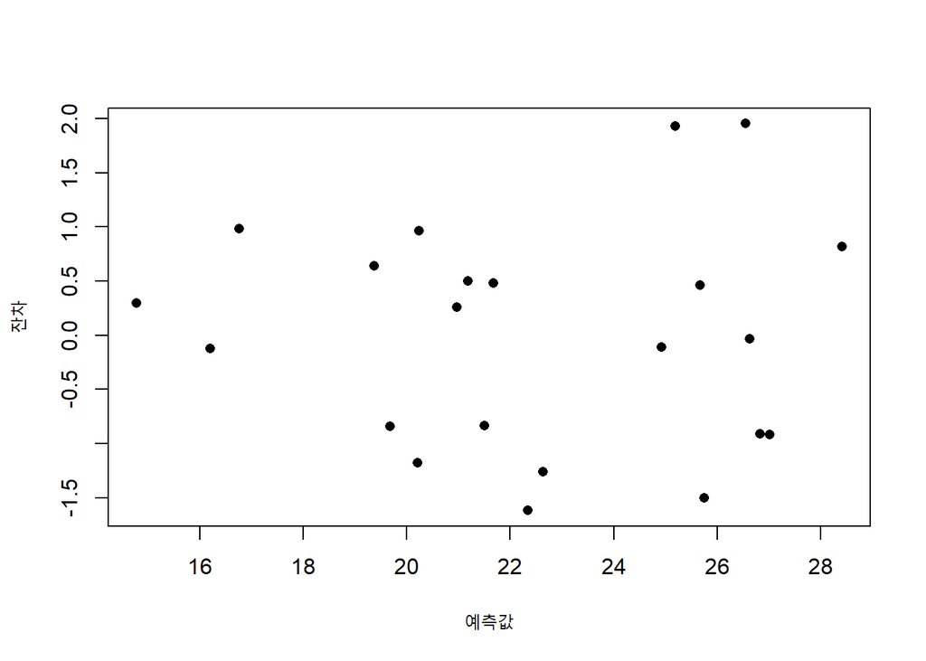

```r
plot(lm_ad$fitted.value, rstandard(lm_ad), xlab = "예측값", ylab = "잔차", pch = 16)
```

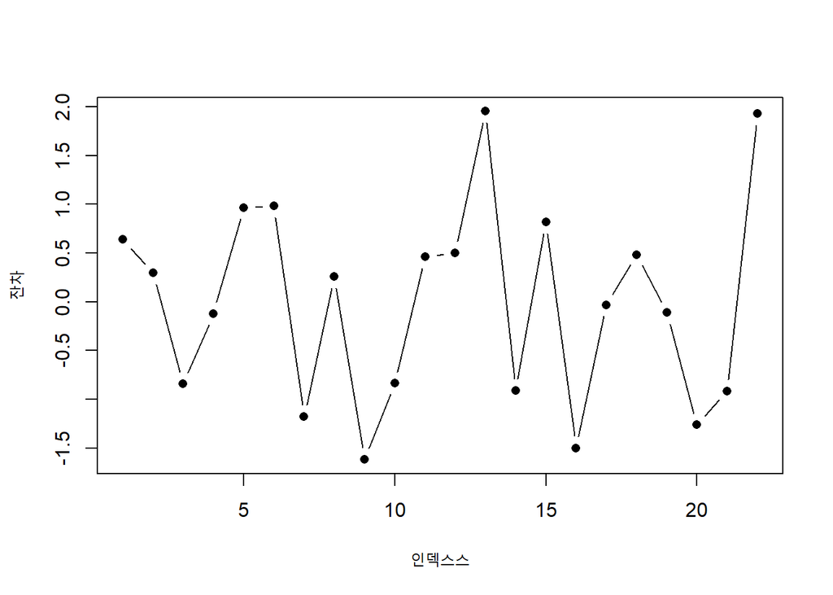

```r
plot(rstandard(lm_ad), xlab = "인덱스스", ylab = "잔차", pch = 16, type = "b")
```

- 예측값, 인덱스 잔차 플롯에서는 모형구축에 문제가 없음 + 예측변수 간의 단순상관계수 또한 모두 매우 작음

```r
ad_A = ad[-2]
lm_ad_A = lm(S_t ~ P_t + E_t + A_.t.1. + P_.t.1., data = ad_A)
summary(lm_ad_A)
```

```
##
## Call:
## lm(formula = S_t ~ P_t + E_t + A_.t.1. + P_.t.1., data = ad_A)
##
## Residuals:
##      Min       1Q   Median       3Q      Max
## -2.30995 -0.74473  0.06867  0.60135  2.54565
##
## Coefficients:
##             Estimate Std. Error t value Pr(>|t|)
## (Intercept)  10.5094     2.4576   4.276 0.000510 ***
## P_t           3.7018     0.7571   4.889 0.000138 ***
## E_t          22.7942     2.1804  10.454 8.04e-09 ***
## A_.t.1.      -0.7692     0.8746  -0.880 0.391388
## P_.t.1.      -0.9687     0.7423  -1.305 0.209273
## ---
## Signif. codes:  0 '***' 0.001 '**' 0.01 '*' 0.05 '.' 0.1 ' ' 1
##
## Residual standard error: 1.35 on 17 degrees of freedom
## Multiple R-squared:  0.9077, Adjusted R-squared:  0.886
## F-statistic: 41.79 on 4 and 17 DF,  p-value: 1.396e-08
```

```r
lm_ad_At = lm(A_t ~ P_t + A_.t.1. + P_.t.1., data = ad)
summary(lm_ad_At)
```

```
##
## Call:
## lm(formula = A_t ~ P_t + A_.t.1. + P_.t.1., data = ad)
##
## Residuals:
##       Min        1Q    Median        3Q       Max
## -0.134930 -0.052396 -0.004111  0.063809  0.146043
##
## Coefficients:
##             Estimate Std. Error t value Pr(>|t|)
## (Intercept)  4.63124    0.12937   35.80  < 2e-16 ***
## P_t         -0.86953    0.04333  -20.07 9.08e-14 ***
## A_.t.1.     -0.86340    0.05024  -17.18 1.30e-12 ***
## P_.t.1.     -0.94689    0.04192  -22.59 1.17e-14 ***
## ---
## Signif. codes:  0 '***' 0.001 '**' 0.01 '*' 0.05 '.' 0.1 ' ' 1
##
## Residual standard error: 0.0776 on 18 degrees of freedom
## Multiple R-squared:  0.9727, Adjusted R-squared:  0.9681
## F-statistic: 213.6 on 3 and 18 DF,  p-value: 2.951e-14
```

- 회귀방정식 : $\hat{A_t} = 4.63 - 0.87P_t - 0.86A_{t-1} - 0.95P_{t-1}$
- $A_t + P_t + A_{t-1} + P_{t-1} \doteq 5$ -> 예산상의 제한성을 반영하는 선형관계로 인해 다중공선성이 발생함

#### 9.4.2 분산확대인자

- 분산확대인자 VIF : 각 예측변수를 나머지 모든 예측변수들로부터 회귀하여 얻어지는 $R^2$을 검색하는 것; $VIF_j = \frac {1} {1-R_j^2}, j = 1, ..., p$
  1. 만약 예측변수 $X_j$가 나머지 모든 예측변수들과 강한 선형관계를 갖는 경우 $R_j$은 1에 접근 -> $VIF_j$는 매우 커짐
  - 통상 VIF > 10이면 그 데이터에 심각한 공선성의 문제가 있다는 신호
  2. 예측변수들 간에 선형적 연관관계가 없는 경우 $R_j^2 = 0$ -> $VIF_j = 1$
  - VIF의 1로부터의 차이 = 공선성의 정도
- $\overline{VIF} = D^2/p = \frac {\sigma^2 \sum_{j = 1}^{p} VIF_j} {p\sigma^2}$ 또한 다중공선성의 측도로 사용가능
  - $D^2$ : OLS추정량과 그 참값으로부터의 제곱거리 / 최소제곱추정량의 정도를 평가하는 또다른 측도 / 값이 작을수록 추정량은 더 정확
- 앞 예시들의 VIF를 통한 다중공선성 진단

```r
library(car)
vif(lm_achv)
```

```
##      FAM     PEER   SCHOOL
## 37.58064 30.21166 83.15544
```

```r
vif(lm_france)
```

```
##     DOPROD      STOCK     CONSUM
## 469.742135   1.049877 469.371343
```

```r
vif(lm_ad)
```

```
##       A_t       P_t       E_t   A_.t.1.   P_.t.1.
## 36.941513 33.473514  1.075962 25.915651 43.520965
```

1. EEO 데이터 : 세 변수(FAM, PEER, SCHOOL) 모두 강한 연관관계를 가지고 있어 그 중 어느 하나를 제거한다 해도 공선성은 사라지지 않음
2. IMPORT 데이터 : VIF에서 DOPROD와 CONSUM은 높은 관계를 가지나 STOCK은 연관성이 없어 회귀방정식에 STOCK와 (CONSUM, DOPROD) 중의 하나만 포함시킨다면 공선성의 문제는 자연히 제거됨
3. ADVER 데이터 : E에 대한 VIF가 1에 매우 가까우므로 이는 다른 예측변수와 상관성이 없으며 나머지 4개 변수 간에 밀접한 선형관계가 있음 -> 여기서 주의할 점은, 특정변수를 제거하는 것이 항상 다중공선성을 감소시키는 가장 좋은 방법은 아니며 전혀 개선되지 않을 때도 있음

#### 9.4.3 상태지수

- 상관계수행렬 : p개 변수 $X_1, ..., X_p$의 짝별 상관계수들을 정방행렬로 나타낸 것
- 만일 어떤 $\lambda$이 완전히 0에 가까운 값을 가지면 원 변수들 사이에 완전한 선형관계가 있다는 것 -> 극단적인 다중공선성을 의미
- 고유값을 통한 다중공선성 진단
  1. 고유값의 역수에 대한 합 : $\sum_{j=1}^{p} \frac {1} {\lambda_j}$ -> 합이 예측변수의 수보다 5배 이상 크면 다중공선성 존재
  2. 상태지수 : $k_j = \sqrt \frac {\lambda_1} {\lambda_j}, j = 1, ..., p$ -> 상태수 $k_p = \sqrt \frac {상관행렬의 최대고유값} {상관행렬의 최소고유값} = \sqrt \frac {\lambda_1} {\lambda_p}$ -> $k_p > 15$이면 데이터의 공선성이 회귀분석에 해로운 결과를 초래한다고 판단함

```r
#(1)교육기회균등
cor_achv_scale <- cor(scale(as.matrix(lm_achv$model)[,-1]))
lambda_achv <- eigen(cor_achv_scale)
#상태지수
sqrt(max(lambda_achv$values)/lambda_achv$values)
```

```
## [1]  1.000000  8.585586 19.258359
```

```r
#(1-1)교육기회균등: `cond.index` 함수 사용, 꼭 중심화 척도화를 먼저 해야 함
library(klaR)
achv_scale_all <- as.data.frame(scale(as.matrix(lm_achv$model)))
cond.index(ACHV ~ FAM + PEER + SCHOOL, data = achv_scale_all)
```

```
## [1]  1.000000  1.718137  8.585586 19.258359
```

```r
#(2)IMPORT (결과 불일치)
cor_france_scale <- cor(scale(as.matrix(lm_france$model)[,-1]))
lambda_france <- eigen(cor_france_scale)
#상태지수
sqrt(max(lambda_france$values)/lambda_france$values)
```

```
## [1]  1.000000  1.509089 44.225733
```

```r
#(3)광고비
cor_ad_scale <- cor(scale(as.matrix(lm_ad$model)[,-1]))
lambda_ad <- eigen(cor_ad_scale)
#상태지수
sqrt(max(lambda_ad$values)/lambda_ad$values)
```

```
## [1]  1.000000  1.149089  1.219017  1.407250 15.294598
```

- 앞 예시들의 상태수를 통한 다중공선성 진단

```r
eigen(cor(achv[-1]))$values
```

```
## [1] 2.951993158 0.040047507 0.007959335
```

```r
eigen(cor(france[3:5]))$values   #책이랑 값이 다름 -> 연도 49 ~ 59 적용 필요해보임
```

```
## [1] 2.083885517 0.915049056 0.001065427
```

```r
eigen(cor(ad[-1]))$values
```

```
## [1] 1.700954740 1.288206906 1.144651635 0.858915342 0.007271377
```

- 이끌어 내야할 결론 : 상태수를 살펴보면 세 데이터 모두에서 다중공선성이 있음을 나타내고 있음

### 연습문제 9.3 가솔린소비량

- 가솔린 자동차의 연비를 결정하는 요인들을 연구하기 위하여 30개 자동차 모형으로부터 데이터를 수집하였다. 반응변수 Y는 1갈론당 주행거리(마일)을 나타내는 가솔린 연료소모량이고, 이에 영향을 끼치는 11개 예측변수들은 자동차의 물리적인, 기계적인 성격과 관련된 것들이다. 표 9.16에 사용된 변수의 내역과 데이터가 주어져있다. 표 9.17의 원데이터는 1975년도 자동차 관련 잡지인 Motor Trend로부터 얻어진 것이다. 여기에서는 데이터에 공선성이 존재하는지를 파악하고자 한다.
1. 예측변수 $X_1, ..., X_11$의 상관계수 행렬을 계산하고, 대응하는 짝별 산점도를 그려라. 공선성의 증거를 찾아보아라.

```r
setwd("C:/Users/X-Note/Desktop")
gasoline = read.table("gasoline.txt", header = T)
head(gasoline)
```

```
##      Y X_1 X_2 X_3  X_4  X_5 X_6 X_7   X_8  X_9 X_.10. X_.11.
## 1 18.9 350 165 260 8.00 2.56   4   3 200.3 69.9   3910      1
## 2 17.0 350 170 275 8.50 2.56   4   3 199.6 72.9   3860      1
## 3 20.0 250 105 185 8.25 2.73   1   3 196.7 72.2   3510      1
## 4 18.3 351 143 255 8.00 3.00   2   3 199.9 74.0   3890      1
## 5 20.1 225  95 170 8.40 2.76   1   3 194.1 71.8   3365      0
## 6 11.2 440 215 330 8.20 2.88   4   3 184.5 69.0   4215      1
```

```r
cor(gasoline[-1])
```

```
##               X_1        X_2        X_3         X_4        X_5         X_6
## X_1     1.0000000  0.9406456  0.9895851 -0.34958682 -0.6714311  0.63996417
## X_2     0.9406456  1.0000000  0.9643592 -0.28989951 -0.5509642  0.76141897
## X_3     0.9895851  0.9643592  1.0000000 -0.32599915 -0.6728661  0.65312630
## X_4    -0.3495868 -0.2898995 -0.3259992  1.00000000  0.4137808  0.03748643
## X_5    -0.6714311 -0.5509642 -0.6728661  0.41378081  1.0000000 -0.21952829
## X_6     0.6399642  0.7614190  0.6531263  0.03748643 -0.2195283  1.00000000
## X_7    -0.7717815 -0.6259445 -0.7461800  0.55823570  0.8717662 -0.27563863
## X_8     0.8649023  0.8027387  0.8641224 -0.30415026 -0.5613315  0.42206800
## X_9     0.8001582  0.7105117  0.7881284 -0.37817358 -0.4534470  0.30038618
## X_.10.  0.9531271  0.8878810  0.9434871 -0.35845879 -0.5798617  0.52036693
## X_.11.  0.8241409  0.7086735  0.8012765 -0.44054570 -0.7546650  0.39548928
##               X_7        X_8        X_9     X_.10.     X_.11.
## X_1    -0.7717815  0.8649023  0.8001582  0.9531271  0.8241409
## X_2    -0.6259445  0.8027387  0.7105117  0.8878810  0.7086735
## X_3    -0.7461800  0.8641224  0.7881284  0.9434871  0.8012765
## X_4     0.5582357 -0.3041503 -0.3781736 -0.3584588 -0.4405457
## X_5     0.8717662 -0.5613315 -0.4534470 -0.5798617 -0.7546650
## X_6    -0.2756386  0.4220680  0.3003862  0.5203669  0.3954893
## X_7     1.0000000 -0.6552065 -0.6551300 -0.7058126 -0.8506963
## X_8    -0.6552065  1.0000000  0.8831512  0.9554541  0.6824919
## X_9    -0.6551300  0.8831512  1.0000000  0.8994711  0.6326677
## X_.10. -0.7058126  0.9554541  0.8994711  1.0000000  0.7530353
## X_.11. -0.8506963  0.6824919  0.6326677  0.7530353  1.0000000
```

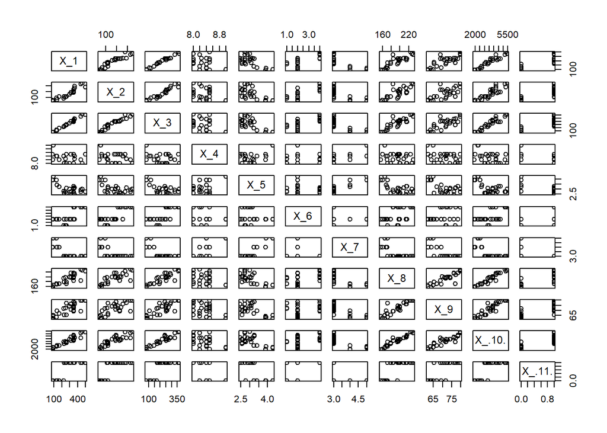

```r
pairs(gasoline[-1])
```

```r
lm_gasoline = lm(Y ~ ., data = gasoline)
summary(lm_gasoline)
```

```
##
## Call:
## lm(formula = Y ~ ., data = gasoline)
##
## Residuals:
##     Min      1Q  Median      3Q     Max
## -5.3498 -1.6236 -0.6002  1.5155  5.2815
##
## Coefficients:
##              Estimate Std. Error t value Pr(>|t|)
## (Intercept) 17.773204  30.508775   0.583   0.5674
## X_1         -0.077946   0.058607  -1.330   0.2001
## X_2         -0.073399   0.088924  -0.825   0.4199
## X_3          0.121115   0.091353   1.326   0.2015
## X_4          1.329034   3.099535   0.429   0.6732
## X_5          5.975989   3.158647   1.892   0.0747 .
## X_6          0.304178   1.289094   0.236   0.8161
## X_7         -3.198576   3.105435  -1.030   0.3167
## X_8          0.185362   0.129252   1.434   0.1687
## X_9         -0.399146   0.323812  -1.233   0.2336
## X_.10.      -0.005193   0.005893  -0.881   0.3898
## X_.11.       0.598655   3.020681   0.198   0.8451
## ---
## Signif. codes:  0 '***' 0.001 '**' 0.01 '*' 0.05 '.' 0.1 ' ' 1
##
## Residual standard error: 3.226 on 18 degrees of freedom
## Multiple R-squared:  0.8353, Adjusted R-squared:  0.7346
## F-statistic: 8.297 on 11 and 18 DF,  p-value: 5.287e-05
```

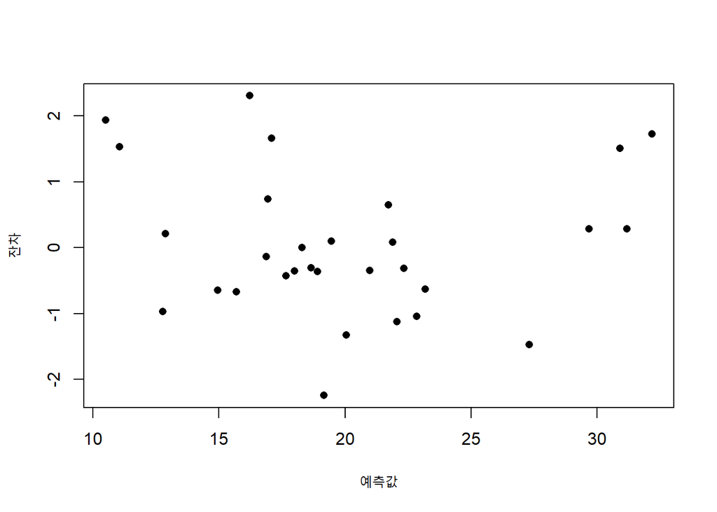

```r
plot(lm_gasoline$fitted.values, rstandard(lm_gasoline), xlab = "예측값", ylab = "잔차", pch = 16)
```

- 잔차플롯을 보았을 때에는 모형에 큰 문제가 없어보인다.
- 결정계수가 0.8353임에도 불구하고 각 예측변수에 대한 개별적 t값은 모두 작아 유의하다고 판단되는 예측변수가 없다. -> 9.3절의 IMPORT 데이터와 동일한 경우로 심각한 다중공선성의 문제가 있다고 생각한다.
- X1, X2, X3, X8, X9, X10 간에 공선성이 존재하는 것으로 예상한다.
2. 상관계수로부터 고유값, 고유벡터, 상태수를 계산하여라. 이 데이터에는 다중공선성이 존재하는가?

```r
eigen(cor(gasoline[-1]))$values
```

```
##  [1] 7.702574847 1.403077880 0.773435643 0.577055424 0.211498935 0.141941470
##  [7] 0.095142049 0.050092536 0.033266309 0.008417705 0.003497202
```

```r
eigen(cor(gasoline[-1]))$vector
```

```
##             [,1]         [,2]        [,3]         [,4]         [,5]        [,6]
##  [1,] -0.3529639 -0.112431387  0.03114403 -0.006932422  0.026272973 -0.09512815
##  [2,] -0.3299718 -0.260762001  0.07836539 -0.194970349 -0.142783457 -0.23889898
##  [3,] -0.3510109 -0.139829772  0.04294522 -0.004153543 -0.084990459 -0.18488343
##  [4,]  0.1610427 -0.552726480  0.11863260  0.785849610  0.096920435  0.09122188
##  [5,]  0.2663779 -0.346997347 -0.43309789 -0.352178691  0.516283052  0.07200995
##  [6,] -0.2047881 -0.548146807  0.41844801 -0.380746710 -0.007176897  0.38287792
##  [7,]  0.3040550 -0.352222407 -0.22122179 -0.134117215 -0.050372348 -0.57691563
##  [8,] -0.3232988 -0.078466513 -0.36961713  0.180329365 -0.200485930 -0.20407455
##  [9,] -0.3026624  0.006019985 -0.54645511  0.094905101  0.106514020  0.51959464
## [10,] -0.3446125 -0.100475266 -0.26679114  0.040652506 -0.028959499 -0.14008874
## [11,] -0.3117090  0.181885175  0.24279993  0.119155548  0.800493659 -0.27479473
##              [,7]        [,8]        [,9]        [,10]        [,11]
##  [1,]  0.26787382 -0.25888638  0.49677393 -0.290946296  0.617904045
##  [2,]  0.34910433  0.05057424 -0.65243209  0.290811120  0.258528596
##  [3,]  0.35518667 -0.06800437  0.03290868 -0.466442937 -0.681570251
##  [4,]  0.09287761 -0.06188507 -0.06292276  0.051311641  0.012735988
##  [5,]  0.06450059 -0.43886854 -0.13804308 -0.086127357 -0.045372936
##  [6,] -0.37681067  0.16574908  0.13359309 -0.004651702 -0.059626414
##  [7,] -0.02079064  0.55944398  0.24949398 -0.055978181  0.049028663
##  [8,] -0.67496023 -0.15486222 -0.25287357 -0.294111256  0.091346835
##  [9,]  0.19659254  0.52415223 -0.01482782 -0.055178229  0.052597726
## [10,] -0.06284718 -0.20261712  0.39402290  0.714256660 -0.259679096
## [11,] -0.16382124  0.22167146 -0.06274209  0.017189710 -0.009773591
```

```r
kp = sqrt(7.702574847/0.003497202)
kp
```

```
## [1] 46.93076
```

```r
eigen(cor(gasoline[-1]))$values[11]
```

```
## [1] 0.003497202
```

```r
eigen(cor(gasoline[-1]))$vector[,11]
```

```
##  [1]  0.617904045  0.258528596 -0.681570251  0.012735988 -0.045372936
##  [6] -0.059626414  0.049028663  0.091346835  0.052597726 -0.259679096
## [11] -0.009773591
```

```r
library(car)
vif(lm_gasoline)
```

```
##        X_1        X_2        X_3        X_4        X_5        X_6        X_7
## 128.834832  43.921063 160.436093   2.057834   7.780750   5.326714  11.735038
##        X_8        X_9     X_.10.     X_.11.
##  20.585810   9.419449  85.675755   5.142547
```

- 회귀적합은 (a)번에서 수행하였다.
- 각 예측변수에 대한 VIF 결과, $X_1, X_2, X_3, X_{10}$에서 매우 큰 값이 나왔으며, $X_8$에서는 15보다는 다소 큰 VIF값이 계산되었다.
- 따라서, $X_1, X_2, X_3, X_{10}$ 변수들은 서로 상관성이 매우 크며 이들에 의해 심각한 다중공선성이 의심되며, $X_8$도 다중공선성에 어느정도 영향을 미친다고 할 수 있다.